# Text analysis of the 10th Republican Presidential candidate debate

## Analysis: Who spoke the most?

We can answer this question in two ways: by the greatest number of speech acts, created when a candidate spoke, and by the total number of words that a candidate spoke in the debate.

To count and compare speech acts, we can tabulate the speech acts and plot the speaker frequency as a barplot.

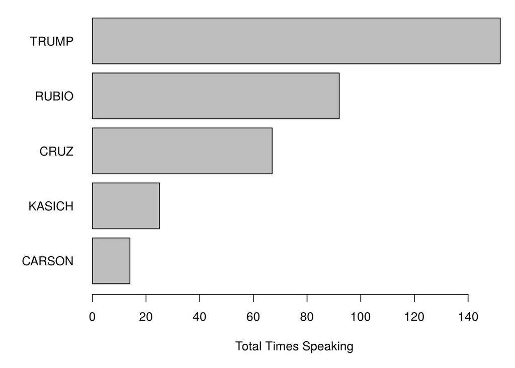

```r
par(mar = c(5, 6, .5, 1))
table(docvars(corpcand, "speaker")) %>%
    sort() %>%
    barplot(horiz = TRUE, las = 1, xlab = "Total Times Speaking")
```

To compare candidates in terms of the total words spoke, we we can get the individual words from `ntoken()`.

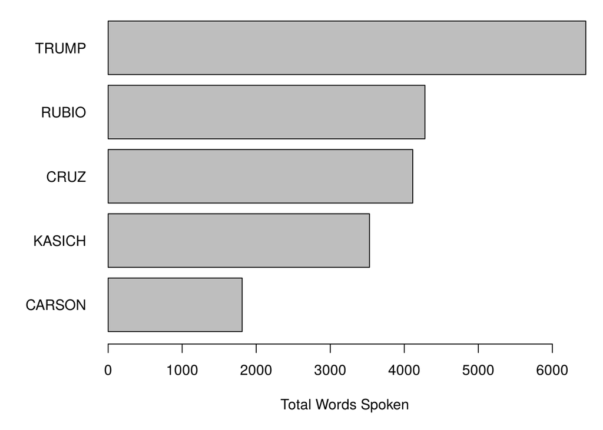

```r
par(mar = c(5, 6, .5, 1))
texts(corpcand, groups = "speaker") %>%
    ntoken(remove_punct = TRUE) %>%
    sort() %>%
    barplot(horiz = TRUE, las = 1, xlab = "Total Words Spoken")
```

In both examples, we can see that Trump spoke the most and Carson the least.

## Analysis: What were they saying?

If we wanted to go further, we convert the segmented corpus into a *document-feature matrix* and apply one of many available psychological dictionaries to analyze the tone of each candidate’s remarks.

Here we demonstrate this using the Regressive Imagery Dictionary, from Martindale, C. (1975) *Romantic Progression: The Psychology of Literary History.* Washington, D.C.: Hemisphere. The code below automatically downloads a version of this dictionary in a format prepared for the WordStat software by [Provalis](http://www.provalisresearch.com), available from http://www.provalisresearch.com/Download/RID.ZIP. **quanteda** can import dictionaries formatted for WordStat, using the `dictionary()` function. We will apply the RID dictionary to find out who used what degree of “glory”-oriented language. (You might be able to guess the results already.)

```r
# get the RID from the Provalis website
download.file("http://provalisresearch.com/Download/RID.ZIP", "RID.zip")
unzip("RID.zip")
data_dictionary_RID <- dictionary(file = "RID.CAT", format = "wordstat")
invisible(file.remove("RID.zip", "RID.CAT", "RID.exc"))
```

This is a nested dictionary object with three primary keys:

```r
names(data_dictionary_RID)
```

```
## [1] "PRIMARY"   "SECONDARY" "EMOTIONS"
```

There are additional keys nested inside each of these. We can show the number of values for each nested entry for the “EMOTIONS” top-level key.

```r
lengths(data_dictionary_RID[["EMOTIONS"]])
## POSITIVE_AFFECT         ANXIETY         SADNESS       AFFECTION      AGGRESSION
##              70              49              75              65             222
##  EXPRESSIVE_BEH           GLORY
##              52              76
```

We can inspect the category we will use (“Glory”) by looking at the last sub-key of the third key, “Emotions”.

```r
tail(data_dictionary_RID[["EMOTIONS"]], 1)
## Dictionary object with 1 key entry.
## - [GLORY]:
##   - admir*, admirabl*, adventur*, applaud*, applaus*, arroganc*, arrogant*, audacity*, awe*, boast*, boastful*, brillianc*, brilliant*, caesar*, castl*, conque*, crown*, dazzl*, eagl*, elit* [ ... and 56 more ]
```

Let’s create a document-feature matrix from the candidate corpus, grouping the documents by speaker. This takes all of the speech acts and combines them by the value of “speaker”, so that the new number of documents is just five (one for each candidate).

```r
dfmatcand <- dfm(corpcand, groups = "speaker", verbose = TRUE)
## Creating a dfm from a corpus input...
##    ... lowercasing
##    ... found 350 documents, 2,510 features
##    ... grouping texts
```

Because the texts are of different lengths, we want to normalize them (by converting the feature counts into vectors of relative frequencies within document):

```r
dfmatcand <- dfm_weight(dfmatcand, "prop")
```

Now we are in a position to apply the RID to the dfm, which matches on the “glob” formatted wildcard expressions that form the values of the RID in our `data_dictionary_RID` object.

```r
dfmatcandRID <- dfm_lookup(dfmatcand, dictionary = data_dictionary_RID)
```

Inspecting this, we see that all tokens have been matched to entries in the Regressive Imagery Dictionary, so that the new features are now “keys”, or dictionary categories, from the RID.

```r
head(dfmatcandRID, nf = 4)
```

| document | PRIMARY.NEED.ORALITY | PRIMARY.NEED.ANALITY | PRIMARY.NEED.SEX | PRIMARY.SENSATION.TOUCH |
| --- | --- | --- | --- | --- |
| CARSON | 0.0024295 | 0.0000000 | 0 | 0.0004859 |
| CRUZ | 0.0012471 | 0.0000000 | 0 | 0.0004157 |
| KASICH | 0.0004850 | 0.0009699 | 0 | 0.0000000 |
| RUBIO | 0.0019897 | 0.0000000 | 0 | 0.0000000 |
| TRUMP | 0.0007628 | 0.0006356 | 0 | 0.0003814 |

We can inspect the most common ones using the `topfeatures()` command, which here we will multiply by 100 to get slightly easier to interpret percentages.

```r
topfeatures(dfmatcandRID * 100, n = 10) %>%
    round(2) %>%
    knitr::kable(col.names = "Percent")
```

|  | Percent |
| --- | --- |
| SECONDARY.ABSTRACT_TOUGHT | 14.51 |
| SECONDARY.SOCIAL_BEHAVIOR | 11.79 |
| SECONDARY.TEMPORAL_REPERE | 11.21 |
| SECONDARY.INSTRU_BEHAVIOR | 10.34 |
| PRIMARY.REGR_KNOL.CONCRETENESS | 9.59 |
| SECONDARY.MORAL_IMPERATIVE | 3.72 |
| EMOTIONS.AGGRESSION | 3.40 |
| PRIMARY.SENSATION.VISION | 2.54 |
| EMOTIONS.AFFECTION | 2.05 |
| SECONDARY.RESTRAINT | 2.02 |

We could probably spend a whole day analyzing this information, but here, let’s simply compare candidates on their relative use of language in the “Emotions: Glory” category of the RID. We do this by slicing out the feature with this label.

```r
dfmatcandRID[, "EMOTIONS.GLORY"]
## Document-feature matrix of: 5 documents, 1 feature (0.0% sparse) and 1 docvar.
##         features
## docs     EMOTIONS.GLORY
##   CARSON   0.0009718173
##   CRUZ     0.0027021409
##   KASICH   0.0016973812
##   RUBIO    0.0019896538
##   TRUMP    0.0045766590
```

To make this a vector, we force it using `as.vector()`, as there is no `drop = TRUE` option for dfm indexing. We then reattach the document labels (the candidate names) to this vector as names. We can plot it using a dotplot, showing that Trump was by far the highest user of this type of language.

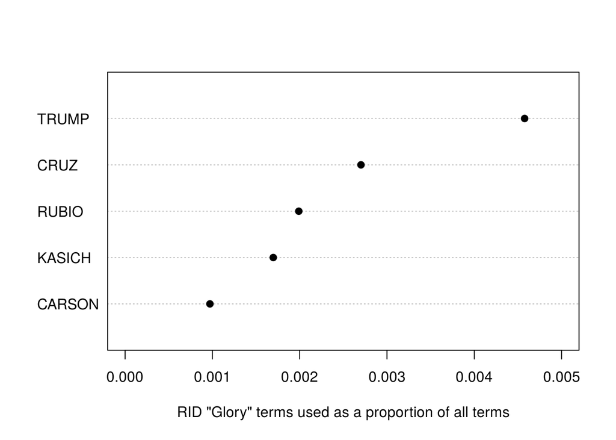

```r
glory <- as.vector(dfmatcandRID[, "EMOTIONS.GLORY"])
names(glory) <- docnames(dfmatcandRID)
dotchart(sort(glory),
         xlab = "RID \"Glory\" terms used as a proportion of all terms",
         pch = 19, xlim = c(0, .005))
```

## Comparing one candidate to another

Thus far, we have employed some fairly simple plotting functions from the **graphics** package. We can also draw on some of **quanteda**’s “textplot” functions designed to work directly with its special object classes.

For instance, we can easily determine which words were used mnost differentially by Trump versus Cruz using some “keyness” statistics and plots. Here we recreate the dfm, remove punctuation and English stopwords, group by speaker, subset by just Trump and Cruz, compute keyness statistics, and then plot the keyness statistics. We can do all of this in one set of piped operations.

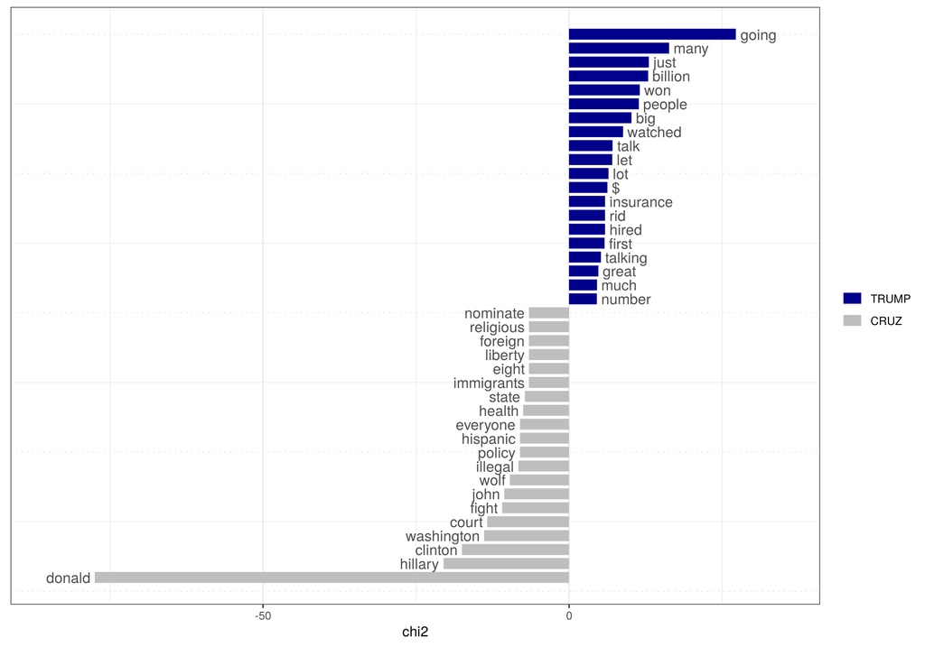

```r
dfm(corpcand, remove_punct = TRUE) %>%
    dfm_remove(stopwords("english")) %>%
    dfm_group(groups = "speaker") %>%
    dfm_subset(speaker %in% c("TRUMP", "CRUZ")) %>%
    textstat_keyness(target = "TRUMP") %>%
    textplot_keyness()
```